# ===== Détecter les Bad Buzz grâce au Deep Learning =====

## Enjeux

Parvenir à **identifier le sentiment d’un tweet** : savoir s’il est positif ou négatif, s’il est susceptible de provoquer un buzz potentiellement nuisible à la réputation de la société Air Paradis.

## Objectifs

Créer le prototype d’un produit IA permettant de prédire le sentiment associé à un Tweet : le modèle doit envoyer un tweet et récupérer la prédiction de sentiment.

Réaliser les trois approches :

1. **Modèle sur mesure simple**
   - un modèle classique de classification binaire
1. **Modèle sur mesure avancé**
   - développer un modèle basé sur des réseaux de neurones profonds
   - avec une couche d'embedding
   - essayer au moins deux word embeddings différents
1. **Modèle avancé BERT**

Finalement, déployer la solution la plus performante via l'API : le service recevra en entrée un tweet et retournera le sentiment associé au tweet prédit par le modèle.

```python
import pandas as pd
import numpy as np
import seaborn as sns
import matplotlib.pyplot as plt
import re
import time
import joblib

# Scikit-learn
from sklearn import pipeline
from sklearn.model_selection import train_test_split, cross_val_score
from sklearn.feature_extraction.text import CountVectorizer
from sklearn.metrics import classification_report, confusion_matrix, f1_score, roc_curve, auc
from sklearn.preprocessing import LabelEncoder
from sklearn.linear_model import LogisticRegression

# NLP
import nltk
```

# Sommaire

Ce notebook présente la mise en place du **Modèle sur mesure simple**.

- Jeu de données
  - Analyse exploratoire
  - Extraction d'un échantillon
- Prétraitement
- Modélisation
- Métrique d'évaluation
- Prédictions
- Sources

# Jeu de données

Chargeons le jeu de données et explorons-le rapidement.

```python
data = pd.read_csv(r'/home/sylwia/Jupyter/P7_BadBuzz/training.1600000.processed.noemoticon.csv',
                   delimiter=',', encoding="ISO-8859-1")
```

```python
data.shape
```

```
(1599999, 6)
```

Le jeu de données est très volumineux - il regroupe 1 600 000 tweets.

```python
data.head()
```

|  | 0 | 1467810369 | Mon Apr 06 22:19:45 PDT 2009 | NO_QUERY | _TheSpecialOne_ | @switchfoot http://twitpic.com/2y1zl - Awww, that's a bummer. You shoulda got David Carr of Third Day to do it. ;D |
| --- | --- | --- | --- | --- | --- | --- |
| 0 | 0 | 1467810672 | Mon Apr 06 22:19:49 PDT 2009 | NO_QUERY | scotthamilton | is upset that he can't update his Facebook by ... |
| 1 | 0 | 1467810917 | Mon Apr 06 22:19:53 PDT 2009 | NO_QUERY | mattycus | @Kenichan I dived many times for the ball. Man... |
| 2 | 0 | 1467811184 | Mon Apr 06 22:19:57 PDT 2009 | NO_QUERY | ElleCTF | my whole body feels itchy and like its on fire |
| 3 | 0 | 1467811193 | Mon Apr 06 22:19:57 PDT 2009 | NO_QUERY | Karoli | @nationwideclass no, it's not behaving at all.... |
| 4 | 0 | 1467811372 | Mon Apr 06 22:20:00 PDT 2009 | NO_QUERY | joy_wolf | @Kwesidei not the whole crew |

Les données que l'on retrouve dans le dataframe sont les suivantes :

- le label - un tweet exprimant un sentiment négatif ou non
- des informations sur les tweets : son contenu, l'ID et le nom de l'utilisateur ayant posté, la date du post, l'info sur query)

Le colonnes n'ont pas d'intitulé, ajoutons-les.

```python
data.columns = ['Label','ID','Date','Flag','User','Text']
```

```python
data.head()
```

|  | Label | ID | Date | Flag | User | Text |
| --- | --- | --- | --- | --- | --- | --- |
| 0 | 0 | 1467810672 | Mon Apr 06 22:19:49 PDT 2009 | NO_QUERY | scotthamilton | is upset that he can't update his Facebook by ... |
| 1 | 0 | 1467810917 | Mon Apr 06 22:19:53 PDT 2009 | NO_QUERY | mattycus | @Kenichan I dived many times for the ball. Man... |
| 2 | 0 | 1467811184 | Mon Apr 06 22:19:57 PDT 2009 | NO_QUERY | ElleCTF | my whole body feels itchy and like its on fire |
| 3 | 0 | 1467811193 | Mon Apr 06 22:19:57 PDT 2009 | NO_QUERY | Karoli | @nationwideclass no, it's not behaving at all.... |
| 4 | 0 | 1467811372 | Mon Apr 06 22:20:00 PDT 2009 | NO_QUERY | joy_wolf | @Kwesidei not the whole crew |

```python
# Sauvegarde du fichier
joblib.dump(data, 'data_origin')
```

```
['data_origin']
```

```python
# Chargement du jeu de données
data = joblib.load('data_origin')
```

## Analyse exploratoire

### Valeurs manquantes

```python
data.isna().sum()
```

```
Label    0
ID       0
Date     0
Flag     0
User     0
Text     0
dtype: int64
```

### Doublons

```python
data.duplicated().sum()
```

```
0
```

```python
#data.drop_duplicates(keep='first', inplace=True)
```

### Types de variables

```python
data.dtypes
```

```
Label     int64
ID        int64
Date     object
Flag     object
User     object
Text     object
dtype: object
```

### Variable target

Analysons la variable-cible `Label` :

```python
data.Label.unique()
```

```
array([0, 4])
```

```python
data.tail()
```

|  | Label | ID | Date | Flag | User | Text |
| --- | --- | --- | --- | --- | --- | --- |
| 1599994 | 4 | 2193601966 | Tue Jun 16 08:40:49 PDT 2009 | NO_QUERY | AmandaMarie1028 | Just woke up. Having no school is the best fee... |
| 1599995 | 4 | 2193601969 | Tue Jun 16 08:40:49 PDT 2009 | NO_QUERY | TheWDBoards | TheWDB.com - Very cool to hear old Walt interv... |
| 1599996 | 4 | 2193601991 | Tue Jun 16 08:40:49 PDT 2009 | NO_QUERY | bpbabe | Are you ready for your MoJo Makeover? Ask me f... |
| 1599997 | 4 | 2193602064 | Tue Jun 16 08:40:49 PDT 2009 | NO_QUERY | tinydiamondz | Happy 38th Birthday to my boo of alll time!!! ... |
| 1599998 | 4 | 2193602129 | Tue Jun 16 08:40:50 PDT 2009 | NO_QUERY | RyanTrevMorris | happy #charitytuesday @theNSPCC @SparksCharity... |

Il s'agit d'une classification binaire. Vérifions la distribution des classes-cibles :

```python
def target_distrib(ft) :
    plt.figure(figsize=(6,6))
    ft.value_counts().plot.bar(title='Tweets positifs vs négatifs', cmap="Accent")
    plt.show()
    print(ft.value_counts())
```

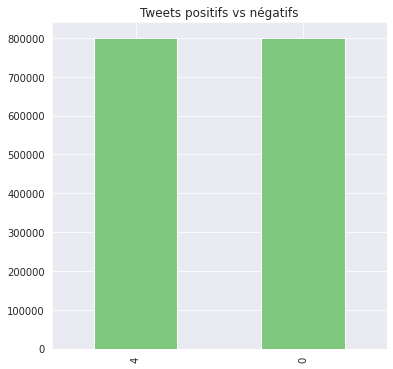

```
4    800000
0    799999
Name: Label, dtype: int64
```

```python
target_distrib(data.Label)
```

Les classes sont très équilibrées : 800 000 tweets positifs (classe 4) versus 800 000 tweets négatifs (classe 0).

## Extraction d'un échantillon

Le jeu de données étant volumineux, nous allons extraire un sample de 16 000 enregistrements.

```python
sample_df = data.groupby("Label").sample(n=8000, random_state=1)
```

```python
sample_df.Label.value_counts()
```

```
0    8000
4    8000
Name: Label, dtype: int64
```

```python
sample_df.head()
```

|  | Label | ID | Date | Flag | User | Text |
| --- | --- | --- | --- | --- | --- | --- |
| 123283 | 0 | 1833881660 | Mon May 18 00:47:53 PDT 2009 | NO_QUERY | CraftyNikki | fingers still broked yesterday wasn't just a ... |
| 513903 | 0 | 2190499049 | Tue Jun 16 02:54:25 PDT 2009 | NO_QUERY | cuzKIMis | @shaulala tck ang dayaa!we weren't allowed to ... |
| 507907 | 0 | 2189022848 | Mon Jun 15 23:04:11 PDT 2009 | NO_QUERY | CodyKennedy | @Zzachary17 awe. I wish I could get on. |
| 564611 | 0 | 2206258397 | Wed Jun 17 06:15:43 PDT 2009 | NO_QUERY | MsKnitSox | @dream0176 sending hugs your way...sorry to he... |
| 727416 | 0 | 2262818074 | Sat Jun 20 23:18:03 PDT 2009 | NO_QUERY | eric_lefuhk | @peacenlove ok |

Pour la suite de l'analyse, nous allons garder uniquement deux variables : le contenu d'un tweet et le label qui lui est attritbué.

```python
sample_df = sample_df[['Label', 'Text']].reset_index().drop(columns=['index'])
#sample_df.drop(column='index')
```

```python
sample_df.head()
```

|  | Label | Text |
| --- | --- | --- |
| 0 | 0 | fingers still broked yesterday wasn't just a ... |
| 1 | 0 | @shaulala tck ang dayaa!we weren't allowed to ... |
| 2 | 0 | @Zzachary17 awe. I wish I could get on. |
| 3 | 0 | @dream0176 sending hugs your way...sorry to he... |
| 4 | 0 | @peacenlove ok |

Nous allons également renommer la classe `4` en `1` :

```python
sample_df['Label'][sample_df['Label']==4]=1
```

Vérifions la distribution des labels suite à la réduction du volume :

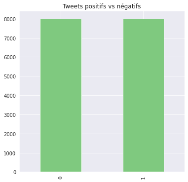

```
0    8000
1    8000
Name: Label, dtype: int64
```

```python
target_distrib(sample_df.Label)
```

```python
# Sauvegarde du fichier
joblib.dump(sample_df, 'sample_df')
```

```
['sample_df']
```

### Variable `Text`

Vérifions la nature des commentaires en termes de longueur. Dans un premier temps on calcule la longueur des énoncés, puis on insère le résultat du calcul dans une nouvelle colonne *length* :

```python
#Nouvelle colonne contenant la longueur des phrases
sample_df_copy=sample_df.copy() # pour éviter le conflit
sample_df_copy['length'] = sample_df_copy.loc[:,'Text'].apply(len)
sample_df_copy.head()
```

|  | Label | Text | length |
| --- | --- | --- | --- |
| 0 | 0 | fingers still broked yesterday wasn't just a ... | 56 |
| 1 | 0 | @shaulala tck ang dayaa!we weren't allowed to ... | 72 |
| 2 | 0 | @Zzachary17 awe. I wish I could get on. | 41 |
| 3 | 0 | @dream0176 sending hugs your way...sorry to he... | 56 |
| 4 | 0 | @peacenlove ok | 15 |

Visualisation de la longueur à l'aide d'un boxplot :

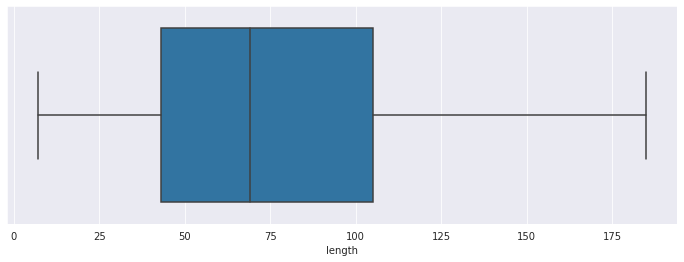

```python
plt.figure(figsize=(12, 4))
sns.boxplot(x=sample_df_copy.length)
plt.show()
```

Les tweets contiennent majoritairement entre 45 et 105 caractères. Vérifions le nombre de caractères et de mots par tweet.

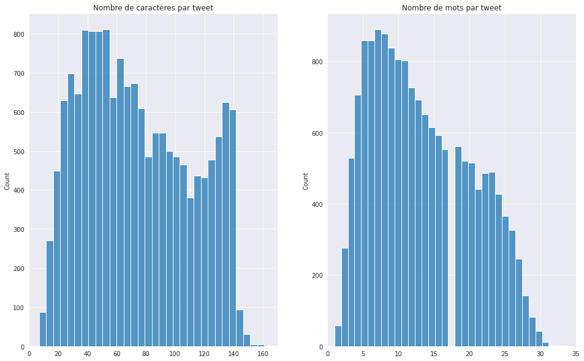

```python
fig, (ax1, ax2) = plt.subplots(1, 2, figsize=(16,10))
sns.set_style('darkgrid')

list_nb_characters = [len(x) for x in sample_df.Text]
list_nb_of_words = [len(x.split()) for x in sample_df.Text]

ax1.set_title('Nombre de caractères par tweet')
sns.histplot(list_nb_characters, ax = ax1)
ax1.set_xlim([0, 170])

ax2.set_title('Nombre de mots par tweet')
sns.histplot(list_nb_of_words, ax = ax2)
ax2.set_xlim([0, 35])

plt.show()
```

**Conclusions** :

- Entre 35 et 75 caractères par tweet en moyenne.
- Les tweets le plus nombreux (800) sont ceux contenant entre 35 et 55 caractères.
- Le nombre de mots par tweet oscille entre 5 et 12, avec un pic à 7.
- Il est intéressant de constater qu'aucun tweet ne contient 17 mots.

## Prétraitement

Lorsqu'il s'agit de données textuelles, nous devons les transformer en chiffres pour qu'elles soient comprises par la machine. `Countvectorizer` est une méthode pour convertir du texte en données numériques. Prenons un exemple du corpus :

```python
corpus=sample_df.copy()
text = list(corpus.Text[0:3])
print(list(corpus.Text[0:3]))
```

```
["fingers still broked  yesterday wasn't just a bad dream!", "@shaulala tck ang dayaa!we weren't allowed to use twiter in the e-class ", '@Zzachary17 awe.  I wish I could get on. ']
```

### Vectorisation d'un échantillon

Application du `CountVectorizer` avec le paramètre `stop_words` activé :

```python
vectorizer = CountVectorizer(stop_words='english')
count_matrix = vectorizer.fit_transform(text)
```

```python
count_array = count_matrix.toarray()
```

```python
df_vect = pd.DataFrame(data=count_array,columns = vectorizer.get_feature_names_out())
print(df_vect)
```

```
   allowed  ang  awe  bad  broked  class  dayaa  dream  fingers  just  \
0        0    0    0    1       1      0      0      1        1     1
1        1    1    0    0       0      1      1      0        0     0
2        0    0    1    0       0      0      0      0        0     0

   shaulala  tck  twiter  use  wasn  weren  wish  yesterday  zzachary17
0         0    0       0    0     1      0     0          1           0
1         1    1       1    1     0      1     0          0           0
2         0    0       0    0     0      0     1          0           1
```

Le résultat est donc un bag of words ! De plus, un prétraitement linguistique a eu lieu (c'est-à-dire le nettoyage et le formatage des données avant de les introduire dans un algorithme d'apprentissage automatique :

- les tokens ont été transformés en minuscules
- suppression de stop words
- suppression de signes de ponctuation
- tokénisation

Ci-dessous le résultat de la vectorisation sur le premier tweet du corpus :

```python
print("Before vectorizing :\n\n", corpus.Text[0], "\n\nAfter vectorizing :\n\n", count_matrix[0])
```

```
Before vectorizing :

 fingers still broked  yesterday wasn't just a bad dream!

After vectorizing :

   (0, 8)	1
  (0, 4)	1
  (0, 17)	1
  (0, 14)	1
  (0, 9)	1
  (0, 3)	1
  (0, 7)	1
```

### Split train et test set

Nous pouvons passer à l'étape de modélisation. Dans un premier temps le splitting du dataset :

```python
X = corpus.Text.values
y = corpus.Label.values

x_train, x_test, y_train, y_test = train_test_split(X, y, test_size = 0.2, random_state = 42)
```

### Vectorisation du corpus

```python
vectorizer = CountVectorizer(stop_words='english', max_df=0.85)
vectorizer.fit(x_train)
```

```
CountVectorizer(max_df=0.85, stop_words='english')
```

```python
X_train = vectorizer.transform(x_train)
X_test = vectorizer.transform(x_test)
```

# Modélisation

```python
# Fonction permettant d'arrondir le temps d'exécution
def round_elapsed_time(time_model):
    time_sec=round((time_model),2)
    return time_sec
```

```python
start_time = time.time()

classifier = LogisticRegression(max_iter=1000)
classifier.fit(X_train, y_train)

end_time = time.time()
time_lr = end_time - start_time
```

```python
time_lr = round_elapsed_time(time_lr)
print ("Temps d'exécution :",time_lr,"secondes")
```

```
Temps d'exécution : 1.35 secondes
```

#### Prédiction

```python
#predicting on the validation set
threshold=0.5
y_proba = classifier.predict_proba(X_test)
```

Affichons les probabilités des 10 premiers tweets correspondantes à leur interprétation :

```python
print("Tweets proba : \n", classifier.predict_proba(X_test)[:,1][:10], "\n")
print("Threshold condition : \n",classifier.predict_proba(X_test)[:,1][:10] > threshold)
```

```
Tweets proba :
 [0.34580853 0.39700485 0.46682552 0.22353169 0.82042418 0.88253274
 0.59119397 0.64100899 0.87793831 0.86072389]

Threshold condition :
 [False False False False  True  True  True  True  True  True]
```

Calculons la variable contenant le résultat de prédictions :

```python
# if prediction is greater or equal to 0,5 than 1, else - 0
y_proba_int = y_proba[:,1] >= 0.5
y_proba_int = y_proba_int.astype(int)
```

```python
y_proba_int[:10]
```

```
array([0, 0, 0, 0, 1, 1, 1, 1, 1, 1])
```

#### Attribution de prédictions aux tweets

```python
test_df = pd.DataFrame(x_test)
test_df['prediction'] = y_proba_int
test_df.head()
```

|  | 0 | prediction |
| --- | --- | --- |
| 0 | @k_shri me too! i wanna be back in muncie | 0 |
| 1 | @HollisRocks LOL nice segway! ;) wish I could ... | 0 |
| 2 | ERASMUS application rejected. | 0 |
| 3 | The sun is shining and I'm inside working | 0 |
| 4 | going to the movies first time in ages | 1 |

## Choix de la métrique

C'est le `score F1` que nous allons utiliser comme métrique d'évaluation. C'est la moyenne pondérée de la précision et du rappel. Ce score prend en compte à la fois les **faux positifs et les faux négatifs**.

- `F1 Score = 2(Recall * Precision) / (Recall + Precision)`
- `Recall = TP/TP+FN`
- `Precision = TP/TP+FP`

En effet, l'idée est de détecter un maximum de tweets négatifs. Tout en sachant que :

- Les vrais négatifs sont labelisés à 0 (TN) => il faut augmenter la Précision
- Les faux positifs sont labelisés à 1 (FN) => il faut également augmenter le Recall afin d'identifier un maximum de vrais positifs.

Nous allons surveiller également l'aire sous la courbe ROC (`AUROC`), le temps écoulé lors de l'entraînement (`Time`) d'un modèle et l'évolution de la perte (`Loss`).

### Accuracy et matrice de confusion

La précision est la proportion de prédictions correctes par rapport aux prédictions totales. Voici comment nous pouvons trouver la précision avec la régression logistique :

```python
acc = classifier.score(X_test, y_test)
print("Accuracy : ", acc)
```

```
Accuracy :  0.7171875
```

L'accuracy est assez élevé. Vérifions le `score F1` et les résultats de la classification :

```python
f1_lr = f1_score(y_test,y_proba_int)
print('F1 score: ',f1_lr)
print('\nClassification Report\n')
print(classification_report(y_test,y_proba_int))
```

```
F1 score:  0.7197274698048932

Classification Report

              precision    recall  f1-score   support

           0       0.72      0.71      0.71      1604
           1       0.71      0.73      0.72      1596

    accuracy                           0.72      3200
   macro avg       0.72      0.72      0.72      3200
weighted avg       0.72      0.72      0.72      3200
```

### Matrice de confusion

```python
cm = confusion_matrix(y_test, y_proba_int, labels = corpus.Label.unique())
df_cm = pd.DataFrame(cm, index = corpus.Label.unique(), columns = corpus.Label.unique())
df_cm
```

|  | 0 | 1 |
| --- | --- | --- |
| 0 | 1133 | 471 |
| 1 | 434 | 1162 |

```python
def model_Evaluate(model):

    # Predict values for Test dataset
    y_pred = model.predict(X_test)
    # Print the evaluation metrics for the dataset.
    print(classification_report(y_test, y_pred))

    # Compute and plot the Confusion matrix
    cf_matrix = confusion_matrix(y_test, y_pred)
    categories = ['Negative', 'Positive']
    group_names = ['True Neg', 'False Pos', 'False Neg', 'True Pos']
    group_percentages = ['{0:.2%}'.format(
        value) for value in cf_matrix.flatten() / np.sum(cf_matrix)]
    labels = [f'{v1}\n{v2}' for v1, v2 in zip(group_names, group_percentages)]
    labels = np.asarray(labels).reshape(2, 2)

    fig, ax = plt.subplots(figsize=(8,6))
    sns.heatmap(cf_matrix, annot=labels, cmap='Oranges', fmt='',
                xticklabels=categories, yticklabels=categories, ax=ax)
    plt.xlabel("Predicted values", fontdict={'size': 14}, labelpad=10)
    plt.ylabel("Actual values", fontdict={'size': 14}, labelpad=10)
    plt.title("Confusion Matrix", fontdict={'size': 18}, pad=20)
```

```
              precision    recall  f1-score   support

           0       0.72      0.71      0.71      1604
           1       0.71      0.73      0.72      1596

    accuracy                           0.72      3200
   macro avg       0.72      0.72      0.72      3200
weighted avg       0.72      0.72      0.72      3200
```

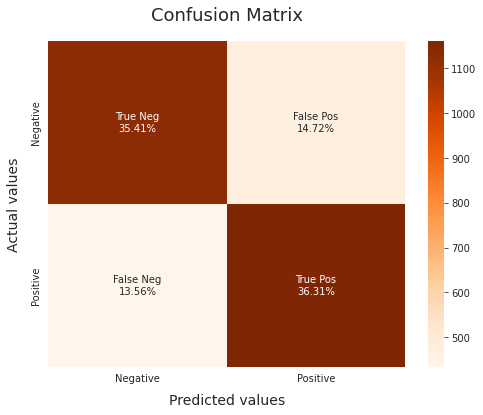

```python
model_Evaluate(classifier)
```

### ROC Curve

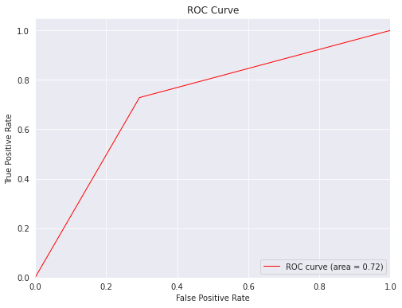

```python
fpr, tpr, thresholds = roc_curve(y_test, y_proba_int)
roc_auc = auc(fpr, tpr)

plt.figure(figsize=(8,6))
plt.plot(fpr, tpr, color='red', lw=1, label='ROC curve (area = %0.2f)' % roc_auc)
plt.xlim([0.0, 1.0])
plt.ylim([0.0, 1.05])
plt.xlabel('False Positive Rate')
plt.ylabel('True Positive Rate')
plt.title('ROC Curve')
plt.legend(loc="lower right")
plt.show()
```

```python
scores = cross_val_score(classifier, X_train, y_train, cv=10)
print('Cross-Validation Accuracy Scores', round(scores.mean(),2))
```

```
Cross-Validation Accuracy Scores 0.72
```

## Prédictions

```python
roc_auc
```

```
0.7172146388414927
```

```python
# Prédiction d'une sentence
# Vectorisation
tweet = 'So happy to be here !'
vectTweet = vectorizer.transform(np.array([tweet]))

# Prediction de la classe du tweet
prediction = classifier.predict(vectTweet)
print('Le tweet est', 'positif.' if prediction[0]==1 else 'négatif.')
```

```
Le tweet est positif.
```

```python
# Prédiction d'une liste de sentences
# Vectorisation
tweetList = ['So happy to be here !', 'I\'m very annoyed to be here !']
vectTweet = vectorizer.transform(np.array(tweetList))

# Prediction de la classe du tweet
prediction = classifier.predict(vectTweet)
for enum, i in enumerate(tweetList) :
    print(i, '=> Le tweet est', 'positif.' if prediction[enum]==1 else 'négatif.')
```

```
So happy to be here ! => Le tweet est positif.
I'm very annoyed to be here ! => Le tweet est négatif.
```

```python
# Sauvegarde du fichier
joblib.dump(vectorizer, '/home/sylwia/Documents/[OC]- Projets/P7/FAST_API/vectors')
joblib.dump(classifier, '/home/sylwia/Documents/[OC]- Projets/P7/FAST_API/model')
```

```
['/home/sylwia/Documents/[OC]- Projets/P7/FAST_API/model']
```

### Fichier récapitulatif

```python
#log_reg = ["/",0.72,0.72,1.19,0.72]
log_reg = ["/",round(acc,2),round(roc_auc,2),time_lr,round(f1_lr,2)]


all_scores = {
    'Logistic Regression':(log_reg),
}


test_df = pd.DataFrame(all_scores)
test_df.index= ['Loss','Acc','AUROC','Time','F1']
test_df.T
```

|  | Loss | Acc | AUROC | Time | F1 |
| --- | --- | --- | --- | --- | --- |
| Logistic Regression | / | 0.72 | 0.72 | 1.35 | 0.72 |

## Sources

- https://medium.com/@lily_su/logistic-regression-accuracy-cross-validation-58d9eb58d6e6